# Homework 1

Davide Cacciatore, Francesca Possenti, Letizia Russo

25/11/2021

# Exercise 1

#### *1.1 Show the validity of the update step (i.e., the one you need to code): increasing by $1$ the $j^{th}$ coordinate of $x^{(k−1)}$ corresponds to add the $j^{th}$ column of $L$ to $y^{(k−1)}$.*

First, we define all the elements:

1. $x$ is a $d$-dimension vector. In his initialized form it contains only zero values. Infact, we can define $x^{(0)} = [0_{(0)},...,0_{(d)}]$.
2. $y$ is a $p$-dimension vector. In his initialized form it contains only zero values. Infact, we can define $y^{(0)} = [0_{(1)}, ...,0_{(p)}]$.
3. $L$ is a $p•d$ matrix. It contains elements drawn indipendently from a normal distribution $N(0,\frac{1}{p})$.

We know that $p<<n<<d$, we can show the situation at the initial step $0$ with some very low fixed value of $d$ and $p$, just to see an example of how it works.

```r
d = 50               #set d
p = 5                #set p
x <- replicate(d, 0) #inital x

# Random values extracted from N(0,1/p) organized into the L matrix
L <- matrix(rnorm(p*d, mean = 0, sd = sqrt(1/p)), nrow = p, ncol = d)

# Compute the dot product
y <- L%*%x

# Check if our initial assumption is right
y
```

```
##      [,1]
## [1,]    0
## [2,]    0
## [3,]    0
## [4,]    0
## [5,]    0
```

Obviously, we get a vector of $0$ as result, because when the algorithm starts the frequency vector $x$ contains only $0$.

At step $k=1$, the frequency vector $x$ is composed by all zeros except the $j^{th}$ element that now is $1$. So, because we are computing a dot product to get $y^{(1)}$, we’re just adding the $j^{th}$ column of $L$ to $y^{(0)}$. Every $i^{th}$ element of $y^{(1)}$, will be equal to:

$$y^{(1)}_{i} = \sum^{d}_{j=1} L_{ij}•x_{j}^{(1)}$$
But, if $x_{j}^{(1)}$ is a vector with all $0$ and only the $j^{th}$ value as $1$, we get that:
$$y^{(1)}_{i} = L_{ij}$$
Let’s see it with a small example in R.

```r
# set j=12
x1 <- c(replicate(11, 0), 1, replicate(d-12, 0)) #x^(1)

# Compute the new dot product
y1 <- L%*%x1

# Check if we are right
y1
```

```
##              [,1]
## [1,]  0.922166135
## [2,] -0.004576459
## [3,]  0.240229547
## [4,] -0.029370186
## [5,] -0.253442778
```

```r
L[,12]
```

```
## [1]  0.922166135 -0.004576459  0.240229547 -0.029370186 -0.253442778
```

```r
y1 == L[,12]
```

```
##      [,1]
## [1,] TRUE
## [2,] TRUE
## [3,] TRUE
## [4,] TRUE
## [5,] TRUE
```

As we can see, we have shown that, fixed $j=12$, we’re just adding the $12^{th}$ column of $L$ to $y^{(0)}$. So, we have that: $y^{(1)} = L_{:,12}$.

Consequentially, at each step $k$, a new $j^{th}$ element of the frequency vector $x$ will increase by $1$. So, we update the vector $y$, adding the $j^{th}$ column of $L$ to the previous version of $y$:
$$y^{(k)} = y^{(k-1)}+L_{:,j}$$

#### *1.2 Use R to generate the matrix $L$ many times (say M = 1000) and setup a suitable simulation study to double-check the JL-lemma. You must play around with different values of $d$, $n$, $\epsilon$ and $p$ (just a few, well chosen values, will be enough). The raw stream $D_n = (i_1, . . . , i_n)$ can be fixed or randomized too, but notice that the probability appearing in Equation (1) simply accounts for the uncertainty implied by the randomness of $L$.*

The *Johnson-Lindenstrauss lemma* says that, for every tolerance $\epsilon > 0$ we set:
$$\Pr \left( (1-\epsilon) \cdot ||x|| \leq ||y|| \leq (1+\epsilon) \cdot ||x|| \right) \geq 1-e^{-\epsilon^2 \cdot p}$$
We define the function *random_projection* in order to double-check the JL-lemma for some input values of $d$, $n$, $\epsilon$ and $p$. This function will output the lemma’s probability and successively and check its correctness.

```r
M <- 1000 #number of simulations

random_projection <- function(d, n, e, p){

  jl = replicate(M, 0)
  # Initialize the counter for the number of times
  # the condition in the JL lemma is verified

  for (i in 1:M) {

    ## This is the algorithm used to compute 'y' and its norm ##

    y <- replicate(p, 0) # Initialize the vector y

    x <- replicate(d, 0) # Initialize the frequency vector x

    # The matrix L contains random number from a N(0,1/p)
    L = matrix(rnorm(p*d, mean = 0, sd = sqrt(1/p)), nrow = p, ncol = d)

    for(k in 1:n) {
      # At each step k, we have an index j picked randomly from a Unif(1,d)
      j = runif(1, min = 1, max = d)

      y = y + L[,j] # For every step k we add the j-th column of L to y

      ## Now we compute x **only** in order to check the JL lemma ##

      x[j] = x[j] + 1 # For every k step the j-th coordinate of x increase by 1

    }

    y_norm = norm(y, type = '2') # Get the norm of y

    x_norm <- norm(x, type = '2') # Get the norm of x

    # Check the JL Lemma
    if ((y_norm >= (1-e)*x_norm) & (y_norm <= (1+e)*x_norm)) {
      jl[i] = 1
    }
  }

  # Check if the result is correct
  print(c('JL is verified:', sum(jl)/M >= 1-exp(-(e^2)*p)))

  return(sum(jl)/M)
}
```

We notice that we don’t need to store the entire stream $D_n$, because at each step a new index $j$ is sampled from a Unif(1,d) and, to compute the norm of $y$, we can consider only the $j^{th}$ column of $L$.

The frequency vector $x$ is required to build the probability of the JL-lemma.

```r
# Run our algorithm to check JL lemma with some test values (valid vor the drag-race).
# d = 5000
# n = 1000
# eps = 0.1
# p = log(n)/eps^2
beg <- Sys.time()

M <- 10000
random_projection(5000, 1000, 0.1, round(log(1000)/0.1^2))
```

```
## [1] "JL is verified:" "TRUE"
```

```
## [1] 1
```

```r
fin <- Sys.time() - beg
print(fin)
```

```
## Time difference of 52.68135 mins
```

Now we want to try our function with different values of $d$, $n$, $\epsilon$ and $p$. We decided to set 6 simulations:

```r
n_sim = 6

# We mantain the same values for d, becuse the lemma ignores the alphabet size d
d = c(10000, 10000, 10000, 10000, 10000, 10000)
n = c(1000, 1000, 100, 100, 100, 100)
e = c(0.15, 0.15, 0.25, 0.25, 0.5, 0.5)
p = c(round(1/e[1]^2), round(log(n[2])/e[2]^2),
      round(1/e[3]^2), round(log(n[4])/e[4]^2),
      round(1/e[5]^2), round(log(n[6])/e[6]^2))
```

In particular, we want to study how the probability computed by the lemma variates, changing the values of $n$ and $\epsilon$ and comparing the result both with $p=\frac{1}{\epsilon^2}$ and $p=\frac{\log(n)}{\epsilon^2}$.

```r
# Initialize a vector that contains the probabilities of each simulation
p_jl <- replicate(0, n_sim)

M <- 1000 # Set 1000 simulations again
for(i in 1:n_sim){
  p_jl[i] <- random_projection(d[i], n[i], e[i], p[i])
}
```

```
## [1] "JL is verified:" "TRUE"
## [1] "JL is verified:" "TRUE"
## [1] "JL is verified:" "TRUE"
## [1] "JL is verified:" "TRUE"
## [1] "JL is verified:" "TRUE"
## [1] "JL is verified:" "TRUE"
```

The JL-lemma is verified for all these values.

We can organize these results in a table.

```r
# Calculate the thresholds for each simulations
pr_threshold = replicate(0, n_sim)
for (i in 1:n_sim){
  pr_threshold[i] = 1-exp(-(e[i]^2)*p[i])
}

# Dataframe with all the values and outputs of the simulations
table <- data.frame(d = d, n = n, e = e, p = p, Pr = unlist(p_jl),
                    Th = unlist(pr_threshold))
table
```

```
##       d    n    e   p    Pr        Th
## 1 10000 1000 0.15  44 0.846 0.6284233
## 2 10000 1000 0.15 307 0.999 0.9989997
## 3 10000  100 0.25  16 0.850 0.6321206
## 4 10000  100 0.25  74 0.998 0.9901963
## 5 10000  100 0.50   4 0.846 0.6321206
## 6 10000  100 0.50  18 0.997 0.9888910
```

In order to analyze better this differences between the two setted $p$, we can produce different plots. We can compare the precision of the $||y||$ approximation in the two cases with two scatterplots.

```r
# Use a function similar to the previous but with the norms of the vectors as output
my_norms <- function(d, n, e, p){

  y_norm <- replicate(M, 0)
  x_norm <- replicate(M, 0)

  for (i in 1:M) {

    ## This is the algorithm used to compute 'y' and its norm ##

    y <- replicate(p, 0) # Initialize the vector y

    x <- replicate(d, 0) # Initialize the frequency vector x

    # The matrix L contains random number from a N(0,1/p)
    L = matrix(rnorm(p*d, mean = 0, sd = sqrt(1/p)), nrow = p, ncol = d)

    for(k in 1:n) {
      # At each step k, we have an index j picked randomly from a Unif(1,d)
      j = runif(1, min = 1, max = d)

      y = y + L[,j] # For every step k we add the j-th column of L to y

      ## Now we compute x **only** in order to check the JL lemma ##

      x[j] = x[j] + 1 # For every k step the j-th coordinate of x increase by 1

    }

    y_norm[i] = norm(y, type = '2') # Get the norm of y

    x_norm[i] <- norm(x, type = '2') # Get the norm of x

  }

  my_norms = list(y_norm = y_norm, x_norm = x_norm)

  return(my_norms)
}
```

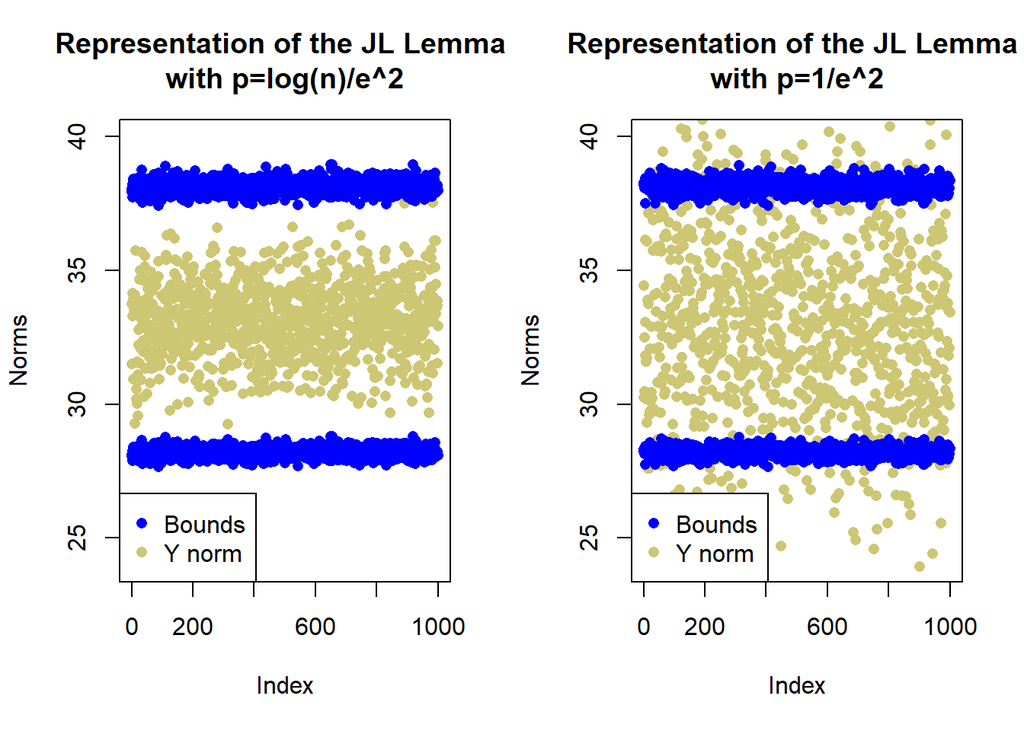

```r
par(mfrow=c(1,2)) # Set 2 plots in one figure

# Calculate the norms when p=log(n)/e^2
# (Input values from the previous table)
norms1 <- my_norms(10000, 1000, 0.15, 307)

# Store in a dataframe the y norm and the two interval bounds
n1 <- data.frame(low.bound = (1-0.15)*norms1$x_norm,
                y = norms1$y_norm,
                upp.bound = (1+0.15)*norms1$x_norm)

# Plot
plot(n1$y, pch=16, col='khaki3', ylim = c(24,40), ylab = 'Norms',
     main = 'Representation of the JL Lemma \nwith p=log(n)/e^2')
points(n1$low.bound, pch=16, col='blue')
points(n1$upp.bound, pch=16, col='blue')
legend('bottomleft', legend=c('Bounds','Y norm'),
       col=c('blue','khaki3'), pch=16)

# Calculate the norms when p=1/e^2
# (Input values from the previous table)
norms2 <- my_norms(10000, 1000, 0.15, 44)

# Store in a dataframe the y norm and the two interval bounds
n2 <- data.frame(low.bound = (1-0.15)*norms2$x_norm,
                y = norms2$y_norm,
                upp.bound = (1+0.15)*norms2$x_norm)

# Plot
plot(n2$y, pch=16, col='khaki3', ylim = c(24,40), ylab = 'Norms',
     main = 'Representation of the JL Lemma \nwith p=1/e^2')
points(n2$low.bound, pch=16, col='blue')
points(n2$upp.bound, pch=16, col='blue')
legend('bottomleft', legend=c('Bounds','Y norm'),
       col=c('blue','khaki3'), pch=16)
```

```r
par(mfrow=c(1,1)) # Back to the default plotting sets
```

On the left, we see that the value of $||y||$ is always in the interval $(1 \pm \epsilon) \cdot ||x||$ and it is well concentrated in the middle. On the right, with a lower $p$, the value of $||y||$ has an higher variability. Infact, there are same norms that are outside the interval. This confirm the results shown in the previous table that with lower $p$ the probability to get an accurate estimate of $||x||$ is lower too.

Now we want to compare the different levels of probabilities and thresholds with the two different kinds of $p$.

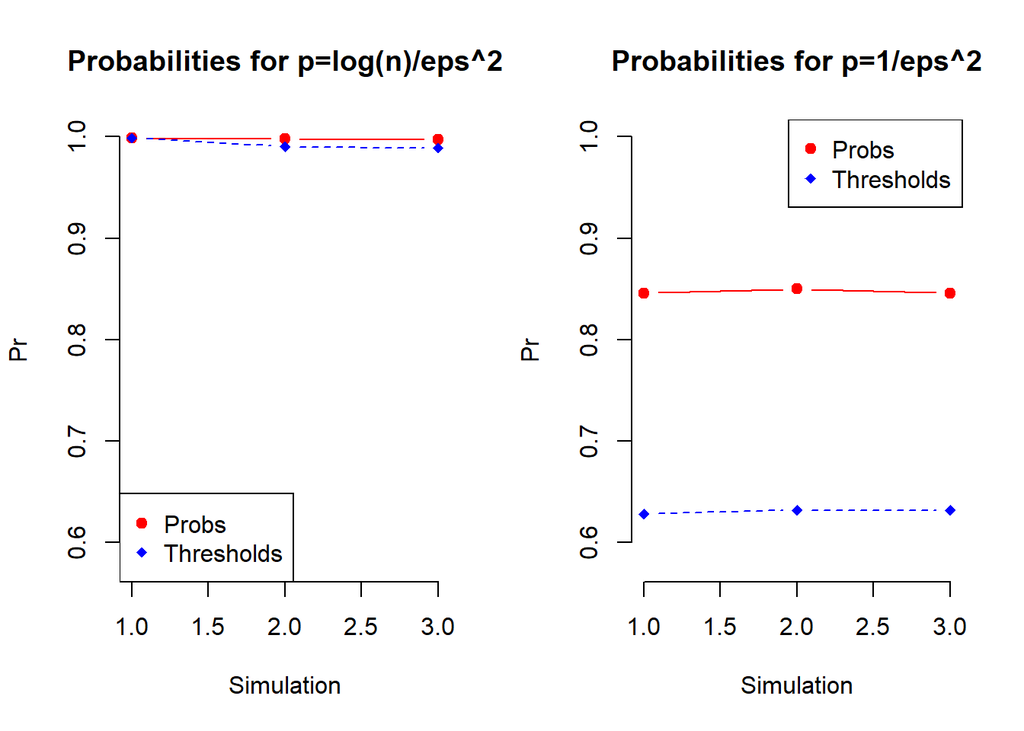

```r
par(mfrow=c(1,2)) # Set 2 plots in one figure

# Plot the probabilities for p=log(n)/eps^2
plot(c(table$Pr[2], table$Pr[4], table$Pr[6]),
     type = "b", frame = FALSE, pch = 19,
     ylim=c(min(table$Th)-0.05,1),
     col = "red", lty = 1, lwd = 1, ylab = 'Pr',
     xlab = 'Simulation', main = 'Probabilities for p=log(n)/eps^2')

# Add line for the different thresolds
lines(c(table$Th[2], table$Th[4], table$Th[6]),
      pch = 18, col = "blue", type = "b",
      lty = 2, lwd = 1)

# Add a legend
legend('bottomleft', legend = c('Probs','Thresholds'),
       col =c('red','blue'), pch = c(19, 18))

# Plot the probabilities for p=1/eps^2
plot(c(table$Pr[1], table$Pr[3], table$Pr[5]),
     type = "b", frame = FALSE, pch = 19,
     ylim=c(min(table$Th)-0.05,1),
     col = "red", lty = 1, lwd = 1, ylab = 'Pr',
     xlab = 'Simulation', main = 'Probabilities for p=1/eps^2')

# Add line for the different thresolds
lines(c(table$Th[1], table$Th[3], table$Th[5]),
      pch = 18, col = "blue", type = "b",
      lty = 2, lwd = 1)

# Add a legend
legend('topright', legend = c('Probs','Thresholds'),
       col =c('red','blue'), pch = c(19, 18))
```

```r
par(mfrow=c(1,2)) # Back to the default plotting sets
```

#### *1.3 The main and only object being updated by the algorithm is the vector y. This vector consumes $p \sim \frac{\log(n)}{\epsilon^2}$ words of space, so. . . have we achieved our goal? Explain.*

We can say that we have achieved the goal of reducing $x$ dimensionality from $d$ to $p$ using an its random projection $y$ that allows us to evaluate the length of $x$ with a nice approximation.

Following the given steps of the algorithm, we had to store the $L$ matrix and this requires $\mathcal{O}(\log(n)\cdot d)$ units of space. It is very expensive and it doesn’t seem to be a real profit from this operation.

This is our **possible solution** to solve this problem. Given the random nature of $L$, a possible solution could be consider at each step of the algorithm a different random p-dimensional vector, whose entries are drawn independently from the same normal distribution as before. The problem could be that if, at one step $k$, we have had to increase by $1$ the same $x_j$ of one or more previous cases, we would have considered the same $j^{th}$ column of $L$ multiple times, but with this algorithm we have different “columns” of $L$ every time. Actually, this is not a big problem, because we are talking of approximations and, given the fact that $d$ must be a large number (even possibly infinite), the chance to get two or more times the same index $j$ are very low, we can say they are almost $0$. (Because $j$ can be any number from $1$ to $d$.) We can try this modified algorithm and try if it works and respect the JL-lemma. We use as inputs some of the ones used in the previous simulations in order to compare the outputs.

```r
M <- 1000 #number of simulations

new_random_projection <- function(d, n, e, p){

  jl = replicate(M, 0)
  # Initialize the counter for the number of times
  # the condition in the JL lemma is verified

  for (i in 1:M) {

    ## This is the algorithm used to compute 'y' and its norm ##

    y <- replicate(p, 0) # Initialize the vector y

    x <- replicate(d, 0) # Initialize the frequency vector x

    for(k in 1:n) {
      # At each step k, we have an index j picked randomly from a Unif(1,d)
      j = runif(1, min = 1, max = d)

      # For every step k we add a random normal p-dimensional vector to y
      y = y + rnorm(p, mean = 0, sd = sqrt(1/p))

      ## Now we compute x **only** in order to check the JL lemma ##

      x[j] = x[j] + 1 # For every k step the j-th coordinate of x increase by 1

    }

    y_norm = norm(y, type = '2') # Get the norm of y

    x_norm <- norm(x, type = '2') # Get the norm of x

    # Check the JL Lemma
    if ((y_norm >= (1-e)*x_norm) & (y_norm <= (1+e)*x_norm)) {
      jl[i] = 1
    }
  }

  # Check if the result is correct
  print(c('JL is verified:', sum(jl)/M >= 1-exp(-(e^2)*p)))

  return(sum(jl)/M)
}
```

```r
new_random_projection(10000, 100, 0.25, 74)
```

```
## [1] "JL is verified:" "TRUE"
```

```
## [1] 0.998
```

```r
new_random_projection(10000, 100, 0.25, 16)
```

```
## [1] "JL is verified:" "TRUE"
```

```
## [1] 0.856
```

We see that this algorithm actually works, outputs nice results and seems to verify the Johnson-Lindenstrauss lemma. The probabilities are also really close to the ones obtained with the other algorithm and this could confirm the assumption we made at the beginning. This way, we can obtain an algorithm that use $\mathcal{O}(\log(n))$ words of space to process the vector $y$. *We had discussions for some of our solutions with Michele Luca Puzzo.*